# Star Tribune analysis: Top 4 agencies

MaryJo Webster, Brandon Stahl, Jennifer Bjorhus

Last updated: 2018-12-27

```
## # A tibble: 9 x 2
##   `year(datereported)` count
##                  <dbl> <int>
## 1                 2010    21
## 2                 2011    10
## 3                 2012    14
## 4                 2013    17
## 5                 2014    30
## 6                 2015   780
## 7                 2016   782
## 8                 2017    17
## 9                 2018     3
```

# Cases reviewed

The Star Tribune requested, from 20 law enforcement agencies statewide, investigative reports on sexual assault reported in 2015 and 2016. We have about half the cases we expected and are waiting on the others. We excluded incest cases or those involving a victim younger than 13. Here are the number of inactive cases we’ve reviewed from the top 4 agencies.

| department | Number_cases |
| --- | --- |
| Minneapolis | 554 |
| St. Paul | 240 |
| Anoka | 124 |
| Duluth | 112 |

# Percent of cases resulting in conviction

Less than 1 in 10 of the cases we reviewed resulted in conviction.

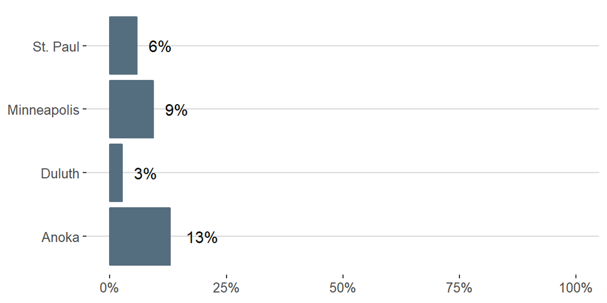

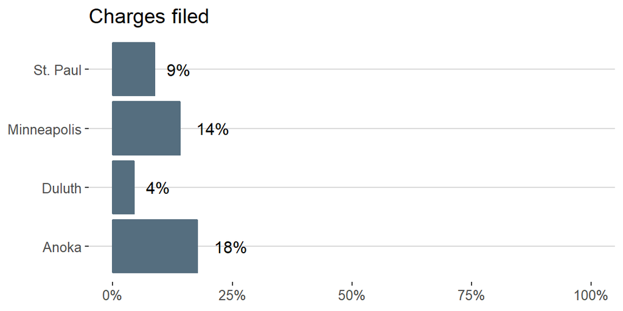

# Percent of cases sent for prosecution

Overall in our analysis, we found that only about 1 in four cases is sent for prosecution. It varies by department, though, since some have a practice of sending most, if not all, cases to prosecutors.

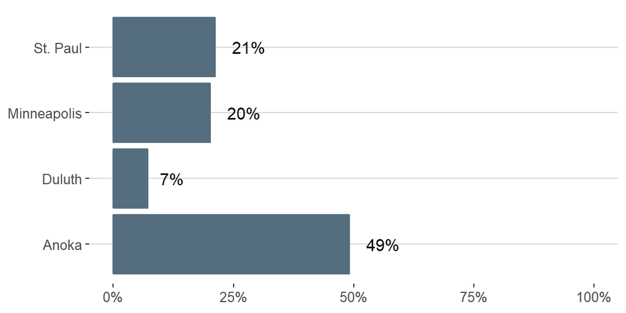

# Case investigations

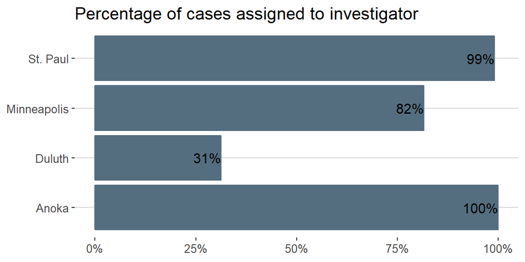

The charts below look at how often investigators took basic policing steps in the cases we reviewed.

A recommended best practice is for investigators to interview the victim after she/he makes an initial report to the officer responding to the initial call.

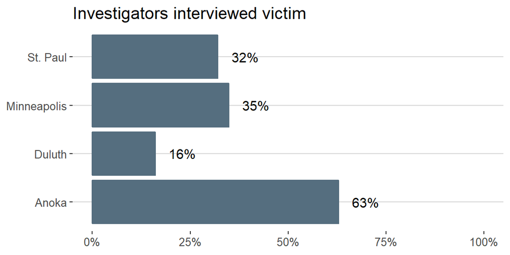

About 70% of the cases we reviewed listed one or more suspect names in the report, yet investigators failed to interview that person more often than not.

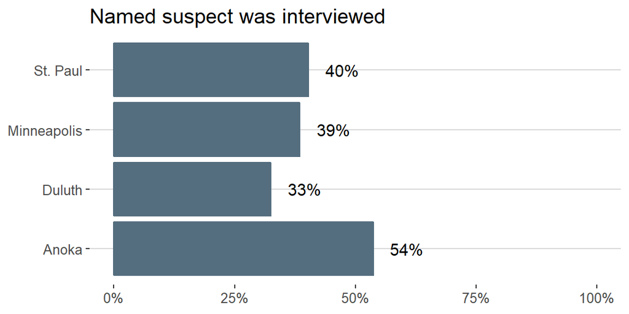

When reviewing cases, we looked for indications of evidence that could’ve been collected but there was no documentation in the report that it was. This might have included DNA, clothing or bed sheets, surveillance video or cell phone data.

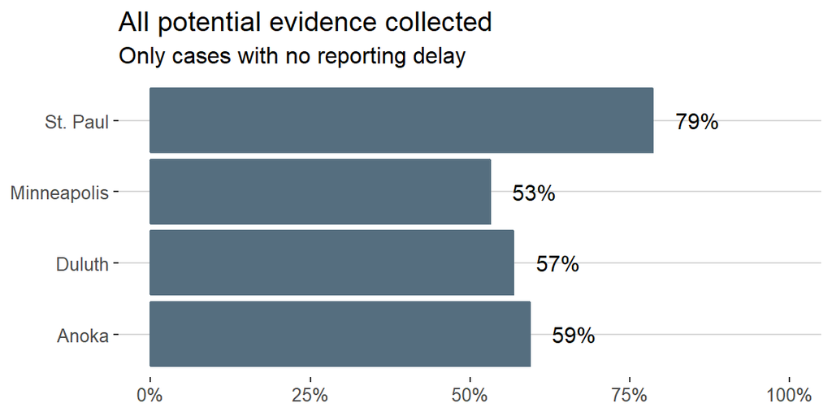

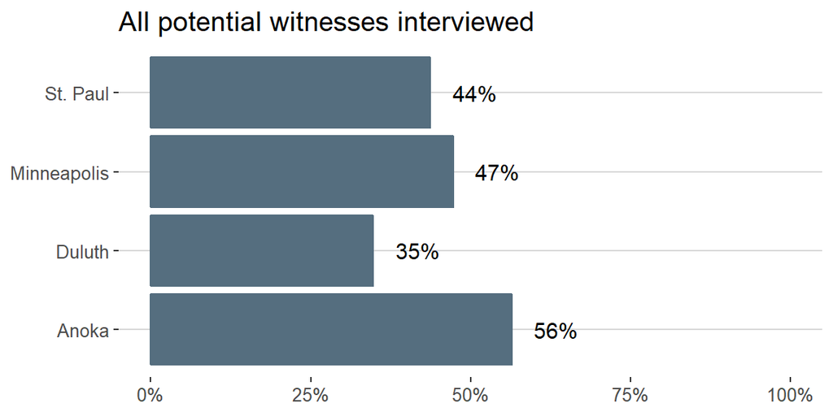

This could include outcry witnesses

# Victim involvement

About one-third of victims either choose to no longer cooperate in an investigation or police are unable to reach them later in the investigation.

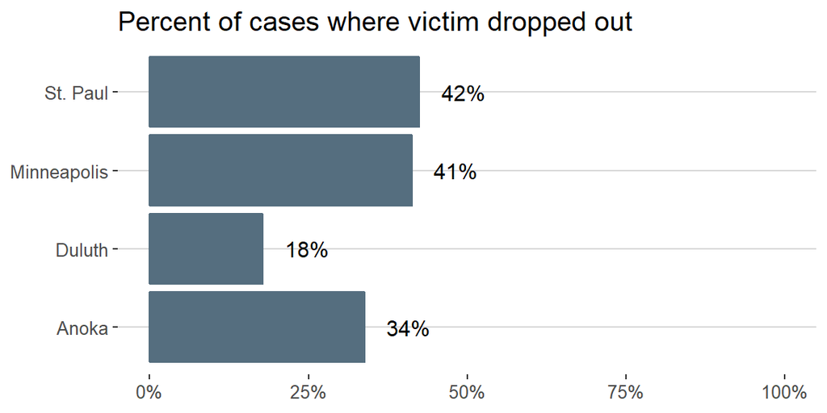

# Cases with intoxicated victim

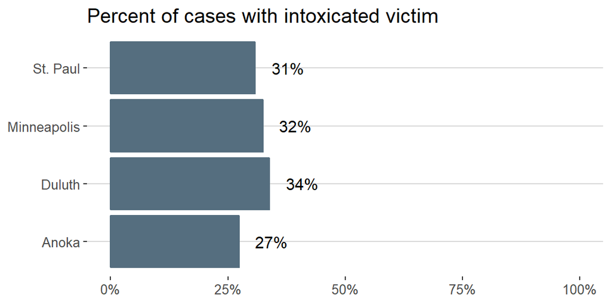

# Number of cases

| top4 | count | pct |
| --- | --- | --- |
| All others | 435 | 0.2969283 |
| Top 4 | 1030 | 0.7030717 |
| Total | 1465 | 1.0000000 |

# compare top 4 to others collectively

Sent for prosecution

|  | sentforprosecution |  |  |  |
| --- | --- | --- | --- | --- |
| top4 | Yes | No | Cannot determine | N/A |
| All others | 46% (200) | 50% (216) | 4% (19) | 0% (0) |
| Top 4 | 23% (232) | 76% (779) | 2% (19) | 0% (0) |
| Total | 29% (432) | 68% (995) | 3% (38) | 0% (0) |

Charges filed

|  | chargesfiled |  |  |  |  |
| --- | --- | --- | --- | --- | --- |
| top4 | Yes | No | Cannot determine | NEED TO CHECK | N/A |
| All others | 16% (68) | 76% (329) | 8% (35) | 0% (2) | 0% (1) |
| Top 4 | 12% (126) | 86% (890) | 1% (13) | 0% (1) | 0% (0) |
| Total | 13% (194) | 83% (1219) | 3% (48) | 0% (3) | 0% (1) |

Conviction

|  | conviction |  |  |  |  |
| --- | --- | --- | --- | --- | --- |
| top4 | Yes | No | Case still pending | Cannot determine | NA_ |
| All others | 8% (34) | 82% (357) | 0% (1) | 9% (38) | 1% (5) |
| Top 4 | 8% (85) | 89% (914) | 0% (3) | 2% (22) | 1% (6) |
| Total | 8% (119) | 87% (1271) | 0% (4) | 4% (60) | 1% (11) |

All evidence collected

|  | evidence2 |  |  |
| --- | --- | --- | --- |
| top4 | All collected | Not all collected | Unknown |
| All others | 67% (293) | 18% (80) | 14% (62) |
| Top 4 | 55% (568) | 29% (295) | 16% (167) |
| Total | 59% (861) | 26% (375) | 16% (229) |

All witnesses interviewed

|  | witness2 |  |  |
| --- | --- | --- | --- |
| top4 | All witnesses interviewed | Not all witnesses interviewed | Unknown |
| All others | 51% (223) | 33% (143) | 16% (69) |
| Top 4 | 46% (476) | 42% (430) | 12% (124) |
| Total | 48% (699) | 39% (573) | 13% (193) |

Victim interviewed

|  | victiminterviewed |  |  |  |  |
| --- | --- | --- | --- | --- | --- |
| top4 | Yes | Attempted | No | Other | N/A |
| All others | 58% (254) | 14% (62) | 23% (98) | 5% (21) | 0% (0) |
| Top 4 | 36% (366) | 27% (282) | 33% (340) | 4% (41) | 0% (1) |
| Total | 42% (620) | 23% (344) | 30% (438) | 4% (62) | 0% (1) |

Named suspect interviewed

|  | suspectinterviewed |  |  |  |  |  |
| --- | --- | --- | --- | --- | --- | --- |
| top4 | Yes | Attempted | No | Other | Suspect unknown | N/A |
| All others | 56% (205) | 10% (35) | 30% (110) | 3% (12) | 1% (3) | 0% (0) |
| Top 4 | 40% (287) | 8% (55) | 50% (354) | 2% (13) | 0% (3) | 0% (1) |
| Total | 46% (492) | 8% (90) | 43% (464) | 2% (25) | 1% (6) | 0% (1) |